# COR 142 C

Sections 3.3-3.4

Dr. Chris Kao

## Summaries for Skewed Distributions

- Use **median** to measure the center of a skewed distribution.
- Use **interquartile range (IQR)** to measure the horizontal spread (variability) of a skewed distribution.

## Median

- When a distribution of a data set is not symmetric, the mean is no longer the appropriate measure of the center.
- The median of a data set is middle number/data point when the data has been sorted in ascending order (from smallest to largest).
- The median is the best measure of the center when the data set is asymmetric.

## Median

- If the data set has an odd number of observations, then the median is the middle number.
  - For example, in the data set {2, 3, 5, 7, 9}, the median is 5.
- If the data set has an even number of observations, then the median is the average of the two middle numbers.
  - For example, in the data set {13, 17, 19, 23}, the median is $(17+19)/2 = 18$.

## Median

**Example 1.** The histogram below shows the distribution of daily high temperature in New York City from May to September of 1973. About half of the days were above 79°F and about half of the days were below 79°F.

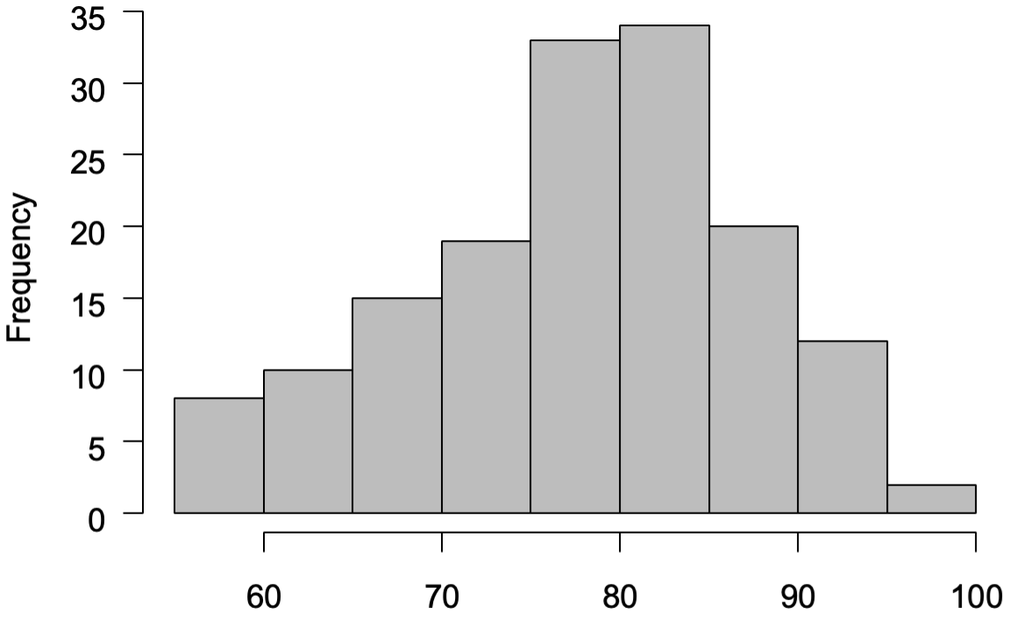

## **Example 1. (continued)**

1. What would we call the value 79°F?
- Since 79°F is the middle data point, it is the **median**.
2. Suppose we knew that the mean was 77.88°F, label both the mean and the median. Which measure do you think is a better typical value for this distribution? Why?
- Since the distribution is left-skewed, the median of 79°F is the better typical value.

## Measuring the Spread of a Skewed Distribution

- The standard deviation measured horizontal spreadusing the distance from the center.
- We do not use mean to measure the center of a skewed distribution, so a different way of measuring the spread of a skewed data set.

## Range, Quartiles, and IQR

- Range: The difference between the largest and the smallest values in a data set.
- Quartiles: Values that divide the data into quarters. Each quartile contains 25% of the data.
  - The **first quartile ($Q_1$)** has 25% of the data below it and 75% of the data above it.
  - The **second quartile ($Q_2$)** has 50% of the data below it and 50% of the data above it.
  - The **third quartile ($Q_3$)** has 75% of the data below it and 25% of the data above it.

## Section 3.4: Comparing Measures of Center

- Symmetric distribution: mean
- Skewed distribution: median
- How to compare measure?

## Appropriate Measure

*Recall:* When working with numerical data, we describe it using the following characteristics.

| Characteristics | Description |
| --- | --- |
| Shape | Symmetric or skewed |
| Center | Mean or median |
| Spread | Standard deviation or IQR |

## Choosing a Measure

- *Primary goal:* Choose the pair of measures that is best suited for the data, depending on its shape.
- *Always* begin with a graph.

| Shape | Measure for Center | Measure for Spread |
| --- | --- | --- |
| Symmetric | mean | SD |
| Skewed | median | IQR |

## Mean vs. Median

- Skewed data and outliers have a large influence on the mean and standard deviation.
- The meidan and IQR are resistant to skewed data and outliers.